# Analysis of Q-Exactive from Bekker-Jensen *et al.*

Christopher Hughes

### Description

This file contains the code for processing the search and quantification output files from the HeLa in-depth proteome publication from Bekker-Jensen *et al.* (PMID: 28601559). **These data were used to make portions of Figure 1 and 2.**

- MGF files were generated using RawQuant.
- The data were searched using SearchCLI and PeptideShakerCLI.
- Raw files were parsed with RawQuant.

### Analysis

These are the libraries we will use somewhere in the analysis.

```r
library(Biostrings)
library(dplyr)
library(ggplot2)
library(RColorBrewer)
library(cowplot)
library(reshape)
library(data.table)
```

First we can look at the distribution of MS2 events to see whether the distribution of events is even across the fractions. For this, we use the parsed files from RawQuant from MS level 2.

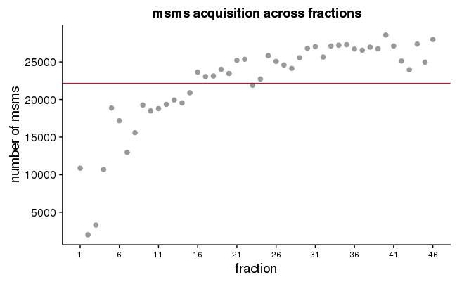

```r
#first grab the files that are output from RawQuant for MS level 2
ms2_quant_files = list.files('/projects/ptx_results/OtherDataSets/2017-June_Jensen_CellSystems/hela_1mg/quant-output',pattern='*MS2ParseData.txt',full.names=TRUE)
#now look at the distribution of MS2 events
ms2_data = data.frame() #data storage object
#iterate over the quantification files to get the numbers of MS2 scans from all files into a single object
for (i in 1:length(ms2_quant_files)){
  ms2_in = read.table(ms2_quant_files[i],header=TRUE,sep='\t') #read in the input file
  ms2_in$fraction = sub(".*?Rep1_(.*?)_MS2ParseData.*", "\\1", ms2_quant_files[i]) #add a fraction column based on the file name
  ms2_data = rbind(ms2_data,ms2_in) #bind the data
}
ms2_data$fraction = as.numeric(ms2_data$fraction) #change the fraction number to a numeric value
ms2_data = ms2_data[order(ms2_data$fraction),] #sort the data object by fraction
saveRDS(ms2_data,'/projects/ptx_analysis/chughes/projects-current/raw-quant/parse-manuscript/Routput/bekker-jensen_all-fractions-ms2-data.rds') #save the data
msms_table = as.data.frame(table(ms2_data$fraction)) #summarise the data to count the MS2 in each fraction
msms_table$Var1 = as.numeric(msms_table$Var1) #change to a numeric value for plotting
#plot the data
msms_plot = ggplot(msms_table, aes(x = Var1, y = Freq)) +
  geom_point(colour='grey60',size=2) +
  labs(x = "fraction", y = 'number of msms', title = 'msms acquisition across fractions') +
  theme(axis.text.x = element_text(size = 9)) +
  geom_hline(yintercept=mean(msms_table$Freq,na.rm=TRUE),color = brewer.pal(6,'RdBu')[1]) +
  scale_y_continuous(breaks = seq(0,30000,5000)) +
  scale_x_continuous(breaks = seq(1,50,5))
msms_plot #call the plot
save_plot('/projects/ptx_analysis/chughes/projects-current/raw-quant/parse-manuscript/Routput/bekker-number-of-msms-46fractions.pdf',msms_plot) #save the plot
```

```r
message('mean number of msms = ',mean(msms_table$Freq,na.rm=TRUE))
```

```
mean number of msms = 22145.1304347826
```

Hmm…the distribution doesn’t look very even. How does this translate to identifications?

```r
####first we need to make an index of protein information from our search database that we will use to add meta data to our IDs
humanDB = readAAStringSet('/projects/ptx_analysis/chughes/databases/uniprot_human-crap-oct2017-FWD.fasta')
#make an annotation index from humanDB
humanIndex = data.frame('meta' = names(humanDB))
humanIndex$accession = sub(".*?\\|(.*?)\\|.*", "\\1", humanIndex$meta) #grab the accession from the header
humanIndex$gene = sub(".*?GN=(.*?) .*", "\\1", humanIndex$meta) #grab the gene from the header
humanIndex$species = sub(".*?OS=(.*?) [GP].*", "\\1", humanIndex$meta) #grab the species from the header
humanIndex = humanIndex[,2:4] #keep the important columns
psm_files = list.files('/projects/ptx_results/OtherDataSets/2017-June_Jensen_CellSystems/hela_1mg/reports-output',pattern='*zip_1_Default_PSM_Report.txt',full.names=TRUE) #locate the desired files
psms_data = data.frame() #make a data storage object
#for this we need the identifications data
for (i in 1:length(psm_files)){
  psm_in = read.table(psm_files[i],header=TRUE,sep='\t')
  psm_f1 = psm_in %>%
    dplyr::select(Protein.s., Sequence, Spectrum.File, Spectrum.Title, m.z, Identification.Charge) %>% #select columns
    dplyr::mutate(Spectrum.Title, scan_num = sub(".*?spectrum (.*?)", "\\1", Spectrum.Title)) %>% #parse out the scan number
    dplyr::mutate(Identification.Charge, id_charge = gsub("[^0-9]", "", Identification.Charge)) %>% #parse out the charge
    dplyr::mutate(Spectrum.Title, fraction = sub(".*?Rep1_(.*?)_MGF\\.mgf", "\\1", Spectrum.File)) %>% #parse the fraction
    dplyr::select(Protein.s., Sequence, scan_num, m.z, id_charge, fraction) %>% #select new columns
    dplyr::mutate(Protein.s., first_accession = sapply(strsplit(as.character(Protein.s.),"\\,"), `[`, 1)) #parse the accession
  #adjust the column names
  colnames(psm_f1) = c('accession_groups','sequence','MS2ScanNumber','id_precursor_mz','id_charge','fraction','accession')
  psm_f2 = merge(psm_f1,humanIndex,by='accession',all.x=TRUE) #add the descriptive data
  psm_f3 = dplyr::filter(psm_f2, !grepl('CONT', accession)) #remove contaminant hits
  #output to the data storage object
  psms_data = rbind(psms_data,psm_f3)
  #output message
  message(i,' files completed')
}
saveRDS(psms_data,'/projects/ptx_analysis/chughes/projects-current/raw-quant/parse-manuscript/Routput/bekker-jensen_46-individual-fractions-identification-data.rds') #save the data
```

Now that we have our saved identification object, we can start to look at the different identification patterns. First we can look at PSM identification rate across the fractions.

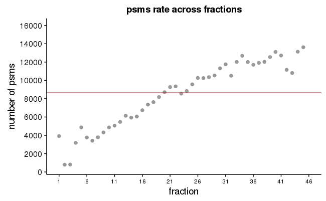

```r
psms = readRDS('/projects/ptx_analysis/chughes/projects-current/raw-quant/parse-manuscript/Routput/bekker-jensen_46-individual-fractions-identification-data.rds') #grab the psms data
ms2_data = readRDS('/projects/ptx_analysis/chughes/projects-current/raw-quant/parse-manuscript/Routput/bekker-jensen_all-fractions-ms2-data.rds') #grab the ms2 data
scans_table = merge(as.data.frame(table(psms$fraction)),as.data.frame(table(ms2_data$fraction)),by='Var1') #make a set of tables
colnames(scans_table) = c('fraction','psms','msms')
scans_table$fraction = as.numeric(as.character(scans_table$fraction)) #convert fraction to numeric for sorting
scans_table = scans_table[order(scans_table$fraction),] #order by fraction
#make the plot
psms_plot = ggplot(scans_table, aes(x = fraction, y = psms)) +
  geom_point(stat='identity',colour='grey60',size=2) +
  labs(x = "fraction", y = 'number of psms', title = 'psms rate across fractions') +
  theme(axis.text.x = element_text(size = 9)) +
  geom_hline(yintercept=40,color = brewer.pal(6,'RdBu')[1],linetype='dashed') +
  geom_hline(yintercept=mean(scans_table$psms,na.rm=TRUE),color = brewer.pal(6,'RdBu')[1]) +
  scale_y_continuous(breaks = seq(0,16000,2000),limits = c(500,16000)) +
  scale_x_continuous(breaks = seq(1,50,5))
psms_plot #call the plot
save_plot('/projects/ptx_analysis/chughes/projects-current/raw-quant/parse-manuscript/Routput/bekker-psms-rate-46fractions.pdf',psms_plot) #save the plot
```

```r
message('Mean psms level across all fractions is ',mean(scans_table$psms,na.rm=TRUE),'.')
```

```
Mean psms level across all fractions is 8640.73913043478.
```

How does this translate to the actual identification rate (ie. number of PSMs / number of MS2 spectra)?

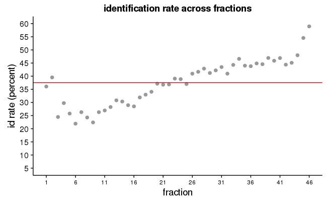

```r
psms = readRDS('/projects/ptx_analysis/chughes/projects-current/raw-quant/parse-manuscript/Routput/bekker-jensen_46-individual-fractions-identification-data.rds') #grab the psms data
ms2_data = readRDS('/projects/ptx_analysis/chughes/projects-current/raw-quant/parse-manuscript/Routput/bekker-jensen_all-fractions-ms2-data.rds') #grab the ms2 data
scans_table = merge(as.data.frame(table(psms$fraction)),as.data.frame(table(ms2_data$fraction)),by='Var1') #make a set of tables
colnames(scans_table) = c('fraction','psms','msms')
scans_table$id_rate = (scans_table$psms / scans_table$msms) * 100 #calculate id rate
scans_table$fraction = as.numeric(as.character(scans_table$fraction)) #convert fraction to numeric for sorting
scans_table = scans_table[order(scans_table$fraction),] #order by fraction
#make the plot
scans_plot = ggplot(scans_table, aes(x = fraction, y = id_rate)) +
  geom_point(stat='identity',colour='grey60',size=2) +
  labs(x = "fraction", y = 'id rate (percent)', title = 'identification rate across fractions') +
  theme(axis.text.x = element_text(size = 9)) +
  geom_hline(yintercept=mean(scans_table$id_rate,na.rm=TRUE),color = brewer.pal(6,'RdBu')[1]) +
  scale_y_continuous(breaks = seq(0,60,5),limits = c(5,60)) +
  scale_x_continuous(breaks = seq(1,50,5))
scans_plot #call the plot
save_plot('/projects/ptx_analysis/chughes/projects-current/raw-quant/parse-manuscript/Routput/bekker-identification-rate-46fractions.pdf',scans_plot) #save the plot
```

```r
message('Mean identification rate across all fractions is ',mean(scans_table$id_rate,na.rm=TRUE),'.')
```

```
Mean identification rate across all fractions is 37.5549373392426.
```

Hmm…so I wonder how well the MS is cycling? Is it triggering many MS2 scans in each cycle? Hitting the topN?

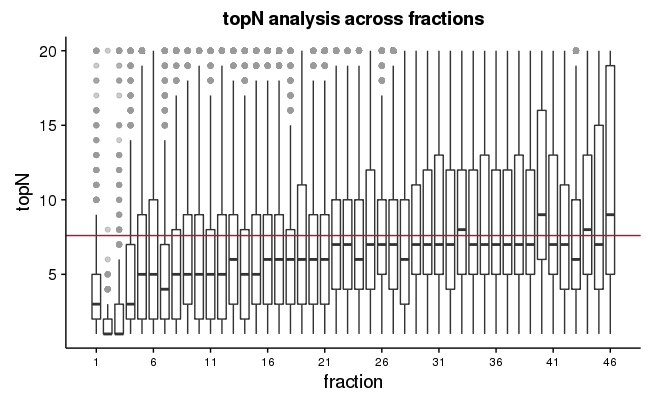

```r
ms2_data = readRDS('/projects/ptx_analysis/chughes/projects-current/raw-quant/parse-manuscript/Routput/bekker-jensen_all-fractions-ms2-data.rds') #grab the ms2 data
ms2_data$topN = 1 #add an extra column as a counter
ms_agg <- setDT(ms2_data)[, lapply(.SD,sum,na.rm=TRUE),by=.(MS1ScanNumber,fraction),.SDcols=c('topN')] #collapse by MS1 scan
setDF(ms_agg) # convert back to dataframe
#make a table of the topN values across fractions
topN_plot = ggplot(ms_agg, aes(fraction,topN,group=fraction)) +
  geom_boxplot(outlier.color = 'gray60',outlier.alpha=0.5) +
  labs(x = "fraction", y = 'topN', title = 'topN analysis across fractions') +
  theme(axis.text.x = element_text(size = 9)) +
  geom_hline(yintercept=mean(ms_agg$topN,na.rm=TRUE),color = brewer.pal(6,'RdBu')[1]) +
  scale_x_continuous(breaks=seq(1,50,5))
topN_plot #call the plot
save_plot('/projects/ptx_analysis/chughes/projects-current/raw-quant/parse-manuscript/Routput/bekker-topN-rate-46fractions.pdf',topN_plot) #save the plot
```

```r
message('Mean topN across all fractions is ',mean(ms_agg$topN,na.rm=TRUE),'.')
```

```
Mean topN across all fractions is 7.60251358290047.
```

So definitely not hitting topN that frequently. What is the overall scan rate based on MS/MS per second?

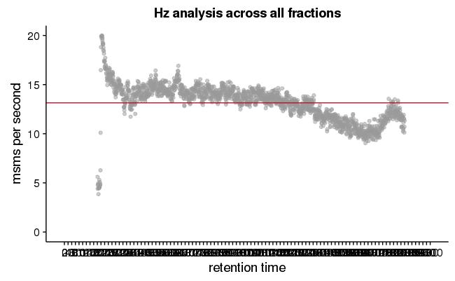

```r
ms2_data = readRDS('/projects/ptx_analysis/chughes/projects-current/raw-quant/parse-manuscript/Routput/bekker-jensen_all-fractions-ms2-data.rds') #grab the ms2 data
ms2_sub = subset(ms2_data, (ms2_data$RetentionTime >= 3) & (ms2_data$RetentionTime < 31)) #subset the data across a specific rt range
ms2_sub$seconds = ms2_sub$RetentionTime *60
ms2_sub$bin_group = cut(ms2_sub$seconds, breaks = seq(180,1860,1))
ms2_sub$numMS2 = 1 #add an MS2 counter
ms2_agg <- setDT(ms2_sub)[, lapply(.SD,sum,na.rm=TRUE),by=.(bin_group,fraction),.SDcols='numMS2'] #collapse by the retention time bin
ms2_agg_fraction <- ms2_agg[, lapply(.SD,mean,na.rm=TRUE),by=.(bin_group),.SDcols='numMS2'] #collapse by the fraction
setDF(ms2_agg_fraction) # convert back to dataframe
ms2_agg_ordered = ms2_agg_fraction[order(ms2_agg_fraction$bin_group),] #order the data by bins
ms2_agg_ordered$bin_start = as.numeric(sub('\\((.*?)\\,.*','\\1',ms2_agg_ordered$bin_group)) #get the bin start point
ms2_agg_ordered$bin_end = as.numeric(sub('.*\\,(.*?)\\].*','\\1',ms2_agg_ordered$bin_group)) #get the bin end point
#now plot the data based on the bins
Hz_scatter = ggplot(ms2_agg_ordered, aes(bin_end,numMS2)) +
  geom_point(colour='gray60',alpha=0.5) +
  labs(x = "retention time", y = 'msms per second', title = 'Hz analysis across all fractions') +
  geom_hline(yintercept=mean(ms2_agg_ordered$numMS2),color = brewer.pal(6,'RdBu')[1]) +
  scale_y_continuous(limits=c(0,20),breaks=seq(0,20,5)) +
  scale_x_continuous(limits=c(0,2000),breaks=seq(0,2000,20))
Hz_scatter #call the plot
save_plot('/projects/ptx_analysis/chughes/projects-current/raw-quant/parse-manuscript/Routput/bekker-Hz-46fractions.pdf',Hz_scatter) #save the plot
```

```r
message('Mean number of MS/MS per second is ',mean(ms2_agg_ordered$numMS2,na.rm=TRUE),'.')
```

```
Mean number of MS/MS per second is 13.1435913870325.
```

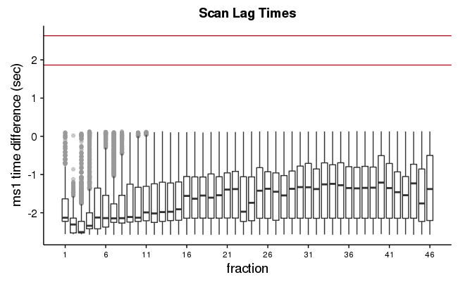

```r
ms1_quant_files = list.files('/projects/ptx_results/OtherDataSets/2017-June_Jensen_CellSystems/hela_1mg/quant-output',pattern='*MS1ParseData.txt',full.names=TRUE)#grab the MS1 RawQuant fies
ms1_data = data.frame() #data storage object
#iterate over the quantification files to get the numbers of MS1 scans
for (i in 1:length(ms1_quant_files)){
  ms1_in = read.table(ms1_quant_files[i],header=TRUE,sep='\t') #read in the file
  ms1_in$fraction = sub(".*?Rep1_(.*?)_MS1ParseData.*", "\\1", ms1_quant_files[i]) #add a fraction column
  ms1_data = rbind(ms1_data,ms1_in) #bind the data
}
ms1_data$fraction = as.numeric(ms1_data$fraction) #change the fraction number to a numeric value
ms1_data = ms1_data[order(ms1_data$fraction),] #sort the data object by fraction
saveRDS(ms1_data,'/projects/ptx_analysis/chughes/projects-current/raw-quant/parse-manuscript/Routput/bekker-jensen_all-fractions-ms1-data.rds') #save the data
#iterate through the fractions and get the between MS2 scan differences
rt_diff = data.frame() #output storage
for (i in 1:46){
  frac_of_interest = subset(ms1_data, fraction == i) #get out the individual fraction
  frac_diff = as.data.frame(diff(frac_of_interest$RetentionTime,1)) #calculate the differences
  frac_diff$fraction = i #add the fraction column back
  colnames(frac_diff)[1] = 'difference' #change column names for the difference values
  frac_diff$seconds = frac_diff$difference*60
  rt_diff = rbind(rt_diff,frac_diff) #bind the data for output
}
#make plot of the data
rt_diff_plot = ggplot(rt_diff, aes(fraction,log2(seconds),group=fraction)) +
  geom_boxplot(outlier.color = 'gray60',outlier.alpha=0.5) +
  labs(x = "fraction", y = 'ms1 time difference (sec)', title = 'Scan Lag Times') +
  theme(axis.text.x = element_text(size = 9)) +
  geom_hline(yintercept=log2(3.64),color = brewer.pal(6,'RdBu')[1]) +
  geom_hline(yintercept=log2(6.2),color = brewer.pal(6,'RdBu')[1]) +
  scale_x_continuous(breaks=seq(1,50,5))
rt_diff_plot #call the plot
save_plot('/projects/ptx_analysis/chughes/projects-current/raw-quant/parse-manuscript/Routput/bekker-rt-difference-46fractions.pdf',rt_diff_plot) #save the plot
```

```r
message('Mean between MS2 scan difference across all fractions is ',mean(rt_diff$seconds,na.rm=TRUE),' seconds.')
```

```
Mean between MS2 scan difference across all fractions is 0.37531418090479 seconds.
```

```r
message('Median between MS2 scan difference across all fractions is ',median(rt_diff$seconds,na.rm=TRUE),' seconds.')
```

```
Median between MS2 scan difference across all fractions is 0.257939999999977 seconds.
```

And lastly, how does all of this translate to metrics based on injection times? Could we afford to slow down a bit?

```r
psms = readRDS('/projects/ptx_analysis/chughes/projects-current/raw-quant/parse-manuscript/Routput/bekker-jensen_46-individual-fractions-identification-data.rds') #grab the psms data
ms2_data = readRDS('/projects/ptx_analysis/chughes/projects-current/raw-quant/parse-manuscript/Routput/bekker-jensen_all-fractions-ms2-data.rds') #grab the ms2 data
colnames(psms)[4] = 'ScanNumber' #change a column name for merging
id_data = merge(psms,ms2_data,by=c('ScanNumber','fraction'),all.x=TRUE) #merge the id and quant data
#get the metrics values
message('proportion of scans at max injection = ',length(which(ms2_data$MS2IonInjectionTime == 15)) / length(ms2_data$MS2IonInjectionTime)) #proportion of scans at max injection
```

```
proportion of scans at max injection = 0.801213536001633
```

```r
message('total number of ms2 = ',length(ms2_data$ScanNumber)) #total number of ms2
```

```
total number of ms2 = 1018676
```

```r
message('number at max inject = ',length(which(ms2_data$MS2IonInjectionTime == 15))) #number at max inject
```

```
number at max inject = 816177
```

```r
message('number not at max inject = ',length(which(ms2_data$MS2IonInjectionTime != 15))) #number not at max inject
```

```
number not at max inject = 202499
```

```r
message('number of psms at max inject = ',length(which(id_data$MS2IonInjectionTime == 15))) #number of psms at max inject
```

```
number of psms at max inject = 277530
```

```r
message('number of psms not at max inject = ',length(which(id_data$MS2IonInjectionTime != 15))) #number of psms not at max inject
```

```
number of psms not at max inject = 119944
```

Done.